[figure not shown]

# [Ahmet Kaya **Data Science Blog**](https://ahmtkaya.github.io/)

# Using natural language processing to build a spam filter for text messages

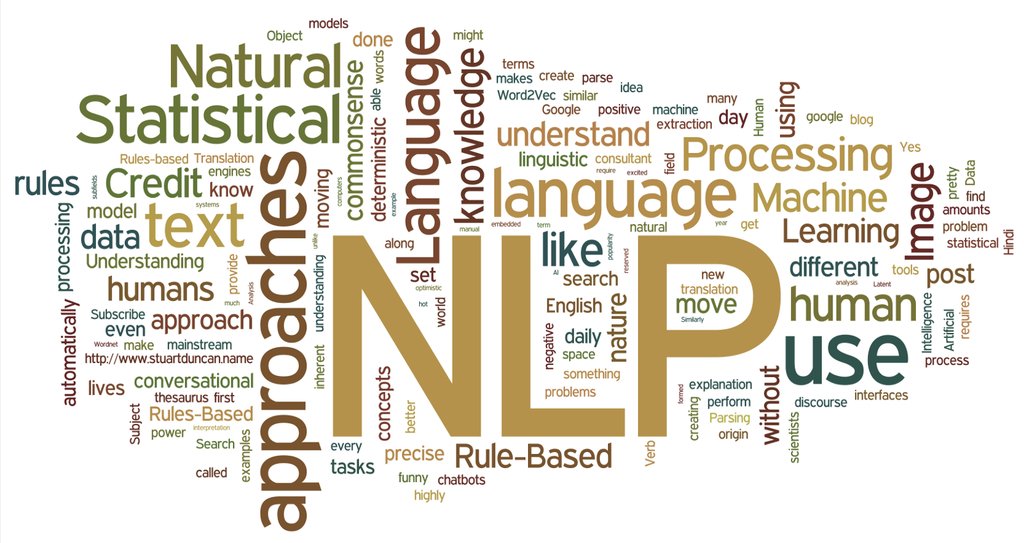

```python
from PIL import Image
Image.open('NLP.png')
```

## Table of contents

Inspecting the dataset

Text preprocessing

Feature engineering

Training and evaluating a model

What terms are the top predictors of spam?

```python
import wordcloud
from wordcloud import WordCloud
import nltk
from nltk.corpus import stopwords
import string
from sklearn import metrics
from sklearn.model_selection import train_test_split
from sklearn.pipeline import Pipeline
from sklearn.feature_extraction.text import CountVectorizer
from sklearn.feature_extraction.text import TfidfTransformer
from sklearn.naive_bayes import MultinomialNB
from sklearn.metrics import classification_report,confusion_matrix
import random as rd
import os
import json
import pandas as pd
import numpy as np
import seaborn as sns
import matplotlib.pyplot as plt
pd.set_option('mode.chained_assignment', None)
```

## 1. Inspecting the dataset

```python
#Read data
path = "Emails/"
labels = ['Ham','Spam']
Category=[]
textdata = []
a=0
for l in labels:
    for file in os.listdir(path+l):
        Category.append(l)
        with open(os.path.join(path+l,file),encoding='utf8',errors="ignore") as f:
            data = f.read()
            textdata.append(data)
df = pd.DataFrame({"Text" : textdata , "Category":Category})
```

```python
df.info()
```

```
<class 'pandas.core.frame.DataFrame'>
RangeIndex: 5857 entries, 0 to 5856
Data columns (total 2 columns):
Text        5857 non-null object
Category    5857 non-null object
dtypes: object(2)
memory usage: 91.6+ KB
```

Since the target variable contains discrete values, this is a classification task. Let's start by placing the target variable in its own table and checking out how the two classes are distributed.

```python
y = df.Category
y.value_counts()
```

```
Ham     4361
Spam    1496
Name: Category, dtype: int64
```

## 2. Text preprocessing

There are many feature engineering strategies for transforming text data into features. Some involve assigning each unique word-like term to a feature and counting the number of occurrences per training example. However, if we were to perform this strategy right now, we'd end up with an absurd number of features, a result of the myriad possible terms. The classifier would take too long to train and likely overfit. As a result, each **NLP** problem requires a tailored approach to determine which terms are relevant and meaningful.

### Normalization

Let's begin by taking a step back and examining the terms of a hypothetical Emails.

```python
#Clean non letter characters and words containing three or less letters
#Clean non letter characters and words containing three or less letters
df = df.replace("[^a-zA-Z]"," ", regex=True)
df = df.replace("\s(\w{1,3})\s",' ', regex=True)
```

```python
df.head()
```

|  | Text | Category |
| --- | --- | --- |
| 0 | Subject rankings thank | Ham |
| 1 | Subject visit enron vince wil... | Ham |
| 2 | Subject research group move the floor hell... | Ham |
| 3 | Subject christmas baskets christmas baskets h... | Ham |
| 4 | Subject japan candidate vince spoke with wh... | Ham |

```python
df.rename(columns = {'Category': 'label', 'Text': 'Email'}, inplace = True)
df['label'] = df['label'].map({'Ham': 0, 'Spam': 1})
df=df.sample(frac=1).reset_index(drop=True)
df.head()
```

|  | Email | label |
| --- | --- | --- |
| 0 | Subject datren williams acceptance are righ... | 0 |
| 1 | Subject position smith norma need a pos... | 0 |
| 2 | Subject transport model andy scale effect t... | 0 |
| 3 | Subject considered unsolicited bulk email fro... | 1 |
| 4 | Subject subject thanks vince vince ka... | 0 |

```python
processed=df.Email
```

```python
processed = processed.str.lower()
```

### Removing stop words

Some words in the English language, while necessary, don't contribute much to the meaning of a phrase. These words, such as "when", "had", "those" or "before", are called stop words and should be filtered out. The Natural Language Toolkit (NLTK), a popular Python library for NLP, provides common stop words.

```python
stop_words = nltk.corpus.stopwords.words('english')
```

```python
processed = processed.apply(lambda x: ' '.join(
    term for term in x.split() if term not in set(stop_words))
)
```

### Stemming

It's likely the corpus contains words with various suffixes such as "distribute", "distributing", "distributor" or "distribution". We can replace these four words with just "distribut" via a preprocessing step called stemming. There are numerous stemming strategies, some more aggressive than others.

```python
porter = nltk.PorterStemmer()
processed = processed.apply(lambda x: ' '.join(
    porter.stem(term) for term in x.split())
)
```

## 3. Feature engineering

### Implementing the tf-idf statistic

```python
from sklearn.feature_extraction.text import CountVectorizer
from sklearn.feature_extraction.text import TfidfTransformer
from sklearn.feature_extraction.text import TfidfVectorizer
from sklearn import svm
```

```python
vectorizer = TfidfVectorizer(ngram_range=(1, 2))
X_ngrams = vectorizer.fit_transform(processed)
```

```python
X_ngrams.shape
```

```
(5857, 319282)
```

## 4. Training and evaluating a model

```python
y_enc=df['label']
```

```python
X_train, X_test, y_train, y_test = train_test_split(
    X_ngrams,
    y_enc,
    test_size=0.2,
    random_state=42,
    stratify=y_enc
)

clf = svm.LinearSVC(loss='hinge')
clf.fit(X_train, y_train)
y_pred = clf.predict(X_test)
metrics.f1_score(y_test, y_pred)
```

```
0.9847715736040609
```

```python
pd.DataFrame(
    metrics.confusion_matrix(y_test, y_pred),
    index=[['actual', 'actual'], ['spam', 'ham']],
    columns=[['predicted', 'predicted'], ['spam', 'ham']]
)
```

|  |  | predicted spam | predicted ham |
| --- | --- | --- | --- |
| actual | spam | 872 | 1 |
|  | ham | 8 | 291 |

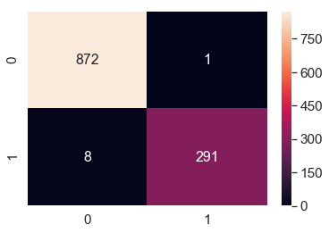

```python
array = confusion_matrix(y_test, y_pred)
df_cm = pd.DataFrame(array, range(2),
                  range(2))
#plt.figure(figsize = (10,7))
sns.set(font_scale=1.4)#for label size
sns.heatmap(df_cm, annot=True,annot_kws={"size": 16}, fmt="d")# font size
```

```python
print(classification_report(y_test, y_pred))
```

```
              precision    recall  f1-score   support

           0       0.99      1.00      0.99       873
           1       1.00      0.97      0.98       299

   micro avg       0.99      0.99      0.99      1172
   macro avg       0.99      0.99      0.99      1172
weighted avg       0.99      0.99      0.99      1172
```

### Diagnosing the model with learning curves

```python
from sklearn.model_selection import learning_curve
from sklearn.model_selection import StratifiedShuffleSplit
sample_space = np.linspace(500, len(df.Email) * 0.8, 10, dtype='int')

train_sizes, train_scores, valid_scores = learning_curve(
    estimator=svm.LinearSVC(loss='hinge', C=1e10),
    X=X_ngrams,
    y=y_enc,
    train_sizes=sample_space,
    cv=StratifiedShuffleSplit(n_splits=10, test_size=0.2, random_state=40),
    scoring='f1',
    n_jobs=-1
)
```

```python
def make_tidy(sample_space, train_scores, valid_scores):
    messy_format = pd.DataFrame(
        np.stack((sample_space, train_scores.mean(axis=1),
                  valid_scores.mean(axis=1)), axis=1),
        columns=['# of training examples', 'Training set', 'Validation set']
    )

    return pd.melt(
        messy_format,
        id_vars='# of training examples',
        value_vars=['Training set', 'Validation set'],
        var_name='Scores',
        value_name='F1 score'
    )
```

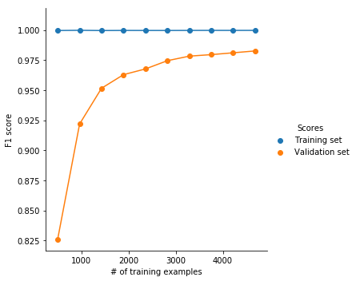

```python
g = sns.FacetGrid(
    make_tidy(sample_space, train_scores, valid_scores), hue='Scores', size=5
)

g.map(plt.scatter, '# of training examples', 'F1 score')
g.map(plt.plot, '# of training examples', 'F1 score').add_legend();
```

Notice the performance on the training set is near perfect regardless of dataset size, which makes sense because we're evaluating the classifier on the same data used to train it. At first, it looks like the classifier is suffering from high variance and is overfitting since the validation scores never reach the same level. However, taking a closer look at the scale of the y-axis makes me believe this issue isn't that pronounced.

### Using nested cross-validation to minimize information leakage

```python
from sklearn.model_selection import GridSearchCV
from sklearn.model_selection import cross_val_score
param_grid = [{'C': np.logspace(-4, 4, 20)}]

grid_search = GridSearchCV(
    estimator=svm.LinearSVC(loss='hinge'),
    param_grid=param_grid,
    cv=StratifiedShuffleSplit(n_splits=10, test_size=0.2, random_state=42),
    scoring='f1',
    n_jobs=-1
)

scores = cross_val_score(
    estimator=grid_search,
    X=X_ngrams,
    y=y_enc,
    cv=StratifiedShuffleSplit(n_splits=10, test_size=0.2, random_state=0),
    scoring='f1',
    n_jobs=-1
)

scores
```

```
array([0.98132428, 0.96763203, 0.98333333, 0.98138748, 0.97800338,
       0.97792869, 0.97959184, 0.98138748, 0.97627119, 0.97822446])
```

```python
scores.mean()
```

```
0.9785084152308429
```

### 5. What terms are the top predictors of spam?

```python
grid_search.fit(X_ngrams, y_enc)
final_clf = svm.LinearSVC(loss='hinge', C=grid_search.best_params_['C'])
final_clf.fit(X_ngrams, y_enc);
```

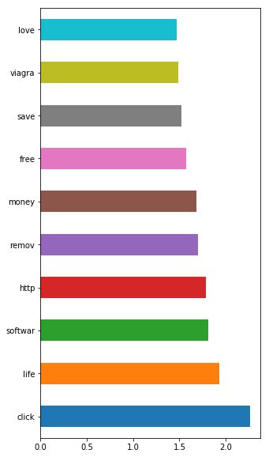

```python
pd.Series(
    final_clf.coef_.T.ravel(),
    index=vectorizer.get_feature_names()
).sort_values(ascending=False)[:10].plot(kind='barh', figsize=(5,10))
```

There are a few obvious ones at the top: *click*, *life*, *softwar*, *http*..etc